# Exercise 9: Multivariate Optimization 4 (Newton-Raphson + Gauss-Newton)

[Optimization in Machine Learning](https://slds-lmu.github.io/website_optimization/)

**Reproducibility**

Produced with Python 3.10 and R 4.4.1. To reproduce, install the pinned package versions below.

**Python**

```bash
pip install numpy==2.0.2 matplotlib==3.10.8
```

**R**

```r
install.packages("remotes")
remotes::install_version("ggplot2", "3.5.1")
remotes::install_version("gridExtra", "2.3")
```

## Setup

We model the data with $\pi: \mathbb{R}^2 \to [0, 1]$ defined as

$$\pi(x_1, x_2) = \frac{1}{1 + \exp((1, x_1, x_2)^\top \boldsymbol{\theta})}$$

and minimize the **Brier loss**

$$\mathcal{R}_\text{emp} = \sum_{i=1}^n \|y^{(i)} - \pi(\mathbf{x}^{(i)})\|_2^2.$$

Note the **flipped sigmoid** convention: $\pi(x) \to 0$ as $\tilde{\mathbf{x}}^\top \boldsymbol{\theta} \to +\infty$ (the opposite of the standard logistic). This is a quirk of this exercise’s parameterization — keep it in mind when reading gradient signs below.

**R**

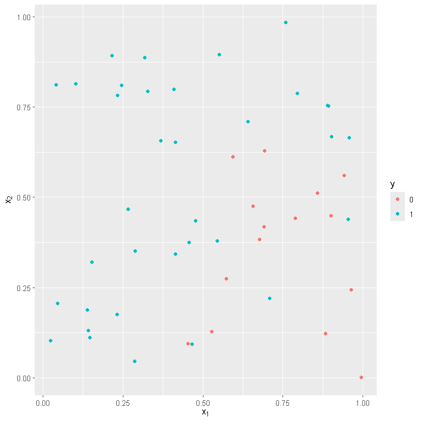

```r
library(ggplot2)

set.seed(123)
n <- 50
X <- matrix(runif(2 * n), ncol = 2)
X_model <- cbind(1, X)                                 # n x 3 design
y <- -((X_model %*% c(0.3, -1, 1) + rnorm(n, 0, 0.3) < 0) - 1)
df <- as.data.frame(X); df$type <- as.character(y)

ggplot(df) +
  geom_point(aes(x = V1, y = V2, color = type)) +
  xlab(expression(x[1])) + ylab(expression(x[2])) +
  labs(color = "y")
```

**Python**

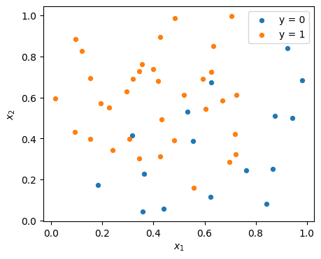

```python
import numpy as np
import matplotlib.pyplot as plt

np.random.seed(123)
n = 50
X = np.random.uniform(size=(n, 2))
X_model = np.column_stack([np.ones(n), X])             # n x 3 design
lin = X_model @ np.array([0.3, -1.0, 1.0]) + np.random.normal(0, 0.3, n)
y = -((lin < 0).astype(int) - 1)
y = y.astype(float)

fig, ax = plt.subplots(figsize=(5, 4))
for label in (0, 1):
    mask = y == label
    ax.scatter(X[mask, 0], X[mask, 1], label=f"y = {label}", s=18)
ax.set_xlabel(r"$x_1$"); ax.set_ylabel(r"$x_2$")
ax.legend()
plt.show()
```

## (a) Gradient of the Brier loss

Show that

$$\nabla_{\boldsymbol{\theta}} \mathcal{R}_\text{emp} = \sum_{i=1}^n 2 \cdot \frac{y^{(i)} \exp(f^{(i)}) - (\exp(-f^{(i)}) + 1)^{-1}}{(\exp(f^{(i)}) + 1)^2} \cdot \tilde{\mathbf{x}}^{(i)}$$

where $\tilde{\mathbf{x}}^{(i)} = (1, x_1^{(i)}, x_2^{(i)})^\top$ and $f^{(i)} = \tilde{\mathbf{x}}^{(i)\top} \boldsymbol{\theta}$.

## (b) Hessian of the Brier loss

Show that

$$\nabla^2_{\boldsymbol{\theta}} \mathcal{R}_\text{emp} = \sum_{i=1}^n 2 \cdot \frac{\exp(f^{(i)})\big(y^{(i)}(1 - \exp(2f^{(i)})) - 1 + 2\exp(f^{(i)})\big)}{(\exp(f^{(i)}) + 1)^4} \cdot \tilde{\mathbf{x}}^{(i)} \tilde{\mathbf{x}}^{(i)\top}.$$

## (c) Non-convexity

Show that $\mathcal{R}_\text{emp}$ is not convex in general.

## (d) Newton-Raphson

Implement Newton-Raphson to minimize $\mathcal{R}_\text{emp}$. Run for $30$ iterations starting at $\boldsymbol{\theta}^{[0]} = \mathbf{0}$. Plot $\mathcal{R}_\text{emp}$ and the parameter trajectory.

## (e) Gauss-Newton

Explain why Gauss-Newton is applicable here, and implement it (30 iterations, $\boldsymbol{\theta}^{[0]} = \mathbf{0}$). Compare its convergence to Newton-Raphson from (d).